# Data Analysis with R

Axel Müller

2018-07-31 05:04:14

## Intro

R is a language for statistical computing and graphics. In contrast to matlab or mathematica it’s free and open source. Hence, an ecosystem of diverse packages is growing rapidly. These packages are designed to make the R experience better, examples are dplyr and tidyr, to improve R’s plotting capabilities, e.g. ggplot2, or to address the specific needs of countless fields such as: Finance, Astronomy, Linguistics, …, and of course Biology. A lot of biological packages especially those that deal with high throughput genomic data are associated with [Bioconductor](https://www.bioconductor.org/).

### Some very useful commands before we get started

Before we get started I’d like to introduce some basic navigation commands:

```
- getwd() will show you your working directory
- setwd(“some/path/to/the/directory”) allows you to change the working directory
- dir() lists the contents of the working directory.
```

Three more commands that come in very handy are:

```
- ?some_command: This yields help pages for a command
- ??some_package: Same but as ?some_command for packages.
- str(some_object): Displays the internal structure of an R object
```

### Simple math with R

```r
40 + 2
```

```
[1] 42
```

```r
44 - 2
```

```
[1] 42
```

```r
6 * 7
```

```
[1] 42
```

```r
84 / 2
```

```
[1] 42
```

```r
sqrt(1764)
```

```
[1] 42
```

```r
6.480741**2
```

```
[1] 42
```

The alternative syntax for this is:

```r
6.480741^2
```

```
[1] 42
```

### Using variables

In R anyting can be assigned to a variable. This is done as follows:

```r
a <- "Hello World"
b <- 21
```

Once the assignment took place you can use the variables instead:

```r
a
```

```
[1] "Hello World"
```

```r
(b + b)^2
```

```
[1] 1764
```

Two more comments to assigning values to variables. Using the “=” sign instead of “<-” is supported but discouraged. Secondly using Rstudio pressing “Alt -” is a shortcut for “<-”.

## Analyzing data

In our webinar series we will give a more detailed introduction to R In this brief introduction, however, we show you how you can analyze data and create compelling graphs with very little background knowledge. Let’s go straight to some already processed RNA-seq data. In our webinar series we will also tell you how to process RNA-seq data yourself using open source software.

The dataset we will work with, GSE79724, can be downloaded from NCBI’s GEO. There are R-packages that facilitate this process but to limit the number of dependencies you need to install we provided the data here

### Dataframes (and Tibbles)

Dataframes are R’s main workhorse. The packages combined in [tidyverse](https://blog.rstudio.org/2016/09/15/tidyverse-1-0-0/) facilitate handling these. In the process they are converted to tibbles, but that’s a detail we can ignore.

#### Loading the data

The data we address here comes in the form of csv files. CSV stands for comma separated values. It’s basically a text file that looks like this:

> header1, header2, header3  
> value1a, value2a, value3a  
> value2a, value2b, value3b  
> another_value1, another_value2, another_value3

We can load the data into a tibble by using the function read_csv, which is part of the readr package. It’s also possible to achieve the same with a base R function (read.csv) but the readr functions are much faster. Another text-based forman that is often used is tsv, tab separated values. TSV files tend to be more human readable and there are equivalent functions in R to load these files. To find out more about read_csv we can execute the following command:

```r
?read_csv
```

The data we want to have a closer look at is in the file data.csv. The right hand panel of Rstudio has a “Files” tab. It displays all the files in the current directory. Clicking on data.csv will show you the contents of the file. For larger files (and slower computers) it’s better not to aim to display the entire file though.

```r
# reading the data.csv file
# we give the path to the file in quotation marks, since we are in the right
# directory already we just have to give the filename, we also tell the function
# that we expects some column names, hence col_names = TRUE
my_data <- read_csv("data.csv", col_names = TRUE)
```

Now that the file is loaded we can have a look. There are several ways to do this. Rstudio offers an interactive option. In the top right panel there is the Environment tab. Here we see all data and all values that are currently in memory. Clicking on my_data will open a new tab in this panel and allows us to observe the file. We should look for example if the file really has column names or if this is not the case. The panel on the right also says that my_data has 25,559 rows and 8 columns. The swiftness of opening and displaying this file obviously depends on the size of the file and specs of the computer. In any case, there is very little value in displaying several thousand lines as we are not going to visually inspect them anyway. We probably just have a look at a few lines at the top to see if the column headers were recognized as such and to get a feeling for what is in the file. So rather than “displaying” 25,559 lines we should be fine by just having a look at 10 lines or so. This can be achieved by base-R’s head() function. But here we are going to promote the use of the tidyverse functions. They are highly optimized and very fast, and the syntax is fairly intuitive: The core principle follows along these lines:

- pick some data
- perform a task on it
- perform the next task
- …
- output the results

In this first case we want to take the data and show the first 10 lines:

```r
my_data %>% head(10)
```

| gene | baseMean_all | baseMean_LG3-LG6-LG9 | baseMean_LG2-LG5-LG8 | foldChange | log2FoldChange | pval | padj |
| --- | --- | --- | --- | --- | --- | --- | --- |
| LOC643401 | 129.44063 | 15.371465 | 243.50980 | 15.841678 | 3.985653 | 2.064903e-14 | 4.514498e-10 |
| ABCA12 | 145.15977 | 28.298929 | 262.02061 | 9.259029 | 3.210861 | 4.977065e-11 | 4.311336e-07 |
| LOC401442 | 34.35765 | 2.480858 | 66.23444 | 26.698195 | 4.738670 | 5.915935e-11 | 4.311336e-07 |
| MAL | 48.23187 | 3.452497 | 93.01124 | 26.940282 | 4.751693 | 9.394450e-11 | 5.134771e-07 |
| REG4 | 407.00315 | 131.200840 | 682.80545 | 5.204277 | 2.379698 | 3.423582e-08 | 1.362002e-04 |
| IBSP | 25.69337 | 3.097313 | 48.28943 | 15.590746 | 3.962618 | 3.737828e-08 | 1.362002e-04 |
| HIST3H2A | 250.54501 | 88.053916 | 413.03610 | 4.690718 | 2.229809 | 5.311537e-07 | 1.658945e-03 |
| PRRT2 | 82.47317 | 25.022757 | 139.92358 | 5.591853 | 2.483326 | 8.190829e-07 | 2.238451e-03 |
| C14orf176 | 48.30360 | 10.187104 | 86.42009 | 8.483283 | 3.084623 | 1.314574e-06 | 3.067987e-03 |
| LOC644656 | 162.67651 | 57.176961 | 268.17605 | 4.690282 | 2.229675 | 1.403278e-06 | 3.067987e-03 |

To string the commands together we use the pipe character (%>%) It’s so commonly used in modern R programming that it has its own keyboard shortcut in Rstudio (Shift-Control-M).

The file contains already a lot of interesting values, such as foldChange and pvalue. But for the purpose of this tutorial we are going to recalculate some of them. First we create a data frame that contains only the gene names, the baseMean_LG3-LG6-LG9, and the baseMean_LG2-LG5-LG8 values.

The process of selecting and manipulating data in a way that suits the analysis is often referred to as data-wrangling. Rstudio offers a very good cheat-sheet for this [here](https://www.rstudio.com/wp-content/uploads/2015/02/data-wrangling-cheatsheet.pdf) The packages of the tidyverse we are going to use for this are dplyr and tidyr. Let’s see how this works in practice:

```r
# create a data frame with the selected columns only
my_calc <- my_data %>%
  select(gene, `baseMean_LG3-LG6-LG9`, `baseMean_LG2-LG5-LG8`)
# the column names contain hyphens, this can lead to some confusion as R
# might interpret it as a minus sign, hence we need to use the ticks.
# check how it worked
my_calc %>% head()
```

| gene | baseMean_LG3-LG6-LG9 | baseMean_LG2-LG5-LG8 |
| --- | --- | --- |
| LOC643401 | 15.371465 | 243.50980 |
| ABCA12 | 28.298929 | 262.02061 |
| LOC401442 | 2.480858 | 66.23444 |
| MAL | 3.452497 | 93.01124 |
| REG4 | 131.200840 | 682.80545 |
| IBSP | 3.097313 | 48.28943 |

Before we move on it makes sense to rename the columns so we don’t have to use ticks all the time.

```r
colnames(my_calc) <- c("gene", "LG369", "LG258")
my_calc %>% head()
```

| gene | LG369 | LG258 |
| --- | --- | --- |
| LOC643401 | 15.371465 | 243.50980 |
| ABCA12 | 28.298929 | 262.02061 |
| LOC401442 | 2.480858 | 66.23444 |
| MAL | 3.452497 | 93.01124 |
| REG4 | 131.200840 | 682.80545 |
| IBSP | 3.097313 | 48.28943 |

```r
# We reassign the output to the initial variable my_calc.
# An alternative lies in using another package (magrittr)
# which supports the operator %<>% which feeds back the output
# into the input variable
my_calc <- my_calc %>%
  mutate(base_mean_all = (LG369 + LG258)/2)
my_calc
```

| gene | LG369 | LG258 | base_mean_all |
| --- | --- | --- | --- |
| LOC643401 | 1.537147e+01 | 243.509802 | 129.440634 |
| ABCA12 | 2.829893e+01 | 262.020606 | 145.159768 |
| LOC401442 | 2.480858e+00 | 66.234444 | 34.357651 |
| MAL | 3.452497e+00 | 93.011244 | 48.231871 |
| REG4 | 1.312008e+02 | 682.805452 | 407.003146 |
| IBSP | 3.097313e+00 | 48.289426 | 25.693370 |
| HIST3H2A | 8.805392e+01 | 413.036103 | 250.545010 |
| PRRT2 | 2.502276e+01 | 139.923578 | 82.473167 |
| C14orf176 | 1.018710e+01 | 86.420088 | 48.303596 |
| LOC644656 | 5.717696e+01 | 268.176050 | 162.676506 |

[output cut: 990 more lines]

Of course R has a function mean that can do the same. In order for it to work here we have to add the function rowwise which tells R that the following operations are done row-wise. This allows the user to do fairly complex operations:

```r
my_calc %>%
  rowwise() %>%
  mutate(base_mean_all = mean(c(LG369, LG258))) %>%
  head()
```

| gene | LG369 | LG258 | base_mean_all |
| --- | --- | --- | --- |
| LOC643401 | 15.371465 | 243.50980 | 129.44063 |
| ABCA12 | 28.298929 | 262.02061 | 145.15977 |
| LOC401442 | 2.480858 | 66.23444 | 34.35765 |
| MAL | 3.452497 | 93.01124 | 48.23187 |
| REG4 | 131.200840 | 682.80545 | 407.00315 |
| IBSP | 3.097313 | 48.28943 | 25.69337 |

We also want to calculate the fold-change:

```r
my_calc <- my_calc %>%
  mutate(foldchange = LG258/LG369)
my_calc
```

| gene | LG369 | LG258 | base_mean_all | foldchange |
| --- | --- | --- | --- | --- |
| LOC643401 | 1.537147e+01 | 243.509802 | 129.440634 | 15.84167799 |
| ABCA12 | 2.829893e+01 | 262.020606 | 145.159768 | 9.25902898 |
| LOC401442 | 2.480858e+00 | 66.234444 | 34.357651 | 26.69819524 |
| MAL | 3.452497e+00 | 93.011244 | 48.231871 | 26.94028232 |
| REG4 | 1.312008e+02 | 682.805452 | 407.003146 | 5.20427653 |
| IBSP | 3.097313e+00 | 48.289426 | 25.693370 | 15.59074642 |
| HIST3H2A | 8.805392e+01 | 413.036103 | 250.545010 | 4.69071814 |
| PRRT2 | 2.502276e+01 | 139.923578 | 82.473167 | 5.59185287 |
| C14orf176 | 1.018710e+01 | 86.420088 | 48.303596 | 8.48328316 |
| LOC644656 | 5.717696e+01 | 268.176050 | 162.676506 | 4.69028165 |

[output cut: 990 more lines]

Obviously, it was also possible to perform the previous two steps in one go.

Now that we calculated the fold changes we can have a look at which genes are up- and which are down-regulated. Let’s take a everything that beyond a 2-fold cut-off.

```r
down_regulated <- my_calc %>%
  filter(foldchange < 0.5)
up_regulated <- my_calc %>%
  filter(foldchange > 2)
```

How many genes are downregulated? For this we count the number of rows (nrow) in the dataframe down_regulated:

```r
nrow(down_regulated)
```

```
[1] 1387
```

and up regulated?

```r
nrow(up_regulated)
```

```
[1] 3129
```

How many genes did we have to start with?

```r
nrow(my_data)
```

```
[1] 25559
```

Ok, now that we know how to select and rename columns, filter by cut-off values, and create new columns we can go back to the original dataset and do some other interesting things.

In case you got lost now it’s the time to catch up again: Let’s have a look at the my_data dataframe again:

```r
my_data %>% head()
```

| gene | baseMean_all | baseMean_LG3-LG6-LG9 | baseMean_LG2-LG5-LG8 | foldChange | log2FoldChange | pval | padj |
| --- | --- | --- | --- | --- | --- | --- | --- |
| LOC643401 | 129.44063 | 15.371465 | 243.50980 | 15.841678 | 3.985653 | 2.064903e-14 | 4.514498e-10 |
| ABCA12 | 145.15977 | 28.298929 | 262.02061 | 9.259029 | 3.210861 | 4.977065e-11 | 4.311336e-07 |
| LOC401442 | 34.35765 | 2.480858 | 66.23444 | 26.698195 | 4.738670 | 5.915935e-11 | 4.311336e-07 |
| MAL | 48.23187 | 3.452497 | 93.01124 | 26.940282 | 4.751693 | 9.394450e-11 | 5.134771e-07 |
| REG4 | 407.00315 | 131.200840 | 682.80545 | 5.204277 | 2.379698 | 3.423582e-08 | 1.362002e-04 |
| IBSP | 25.69337 | 3.097313 | 48.28943 | 15.590746 | 3.962618 | 3.737828e-08 | 1.362002e-04 |

Can you tell me how many rows this new dataframe has?

```r
my_data_p05 <- my_data %>%
  filter(pval < 0.05)
nrow(my_data_p05)
```

```
[1] 1124
```

```r
my_data_p05 %>% head()
```

| gene | baseMean_all | baseMean_LG3-LG6-LG9 | baseMean_LG2-LG5-LG8 | foldChange | log2FoldChange | pval | padj |
| --- | --- | --- | --- | --- | --- | --- | --- |
| LOC643401 | 129.44063 | 15.371465 | 243.50980 | 15.841678 | 3.985653 | 2.064903e-14 | 4.514498e-10 |
| ABCA12 | 145.15977 | 28.298929 | 262.02061 | 9.259029 | 3.210861 | 4.977065e-11 | 4.311336e-07 |
| LOC401442 | 34.35765 | 2.480858 | 66.23444 | 26.698195 | 4.738670 | 5.915935e-11 | 4.311336e-07 |
| MAL | 48.23187 | 3.452497 | 93.01124 | 26.940282 | 4.751693 | 9.394450e-11 | 5.134771e-07 |
| REG4 | 407.00315 | 131.200840 | 682.80545 | 5.204277 | 2.379698 | 3.423582e-08 | 1.362002e-04 |
| IBSP | 25.69337 | 3.097313 | 48.28943 | 15.590746 | 3.962618 | 3.737828e-08 | 1.362002e-04 |

## Plotting

### Volcano Plot

Let’s start of by doing a volcano plot. ggplot2 is a very powerful graphics package in R. It’s also part of the tidyverse. ggplot2 uses [grammar of graphics](http://vita.had.co.nz/papers/layered-grammar.pdf)

Let’s see how this works in practice. First we create a cut-off for our data similar as we did before

```r
#create a threshold with an absolute fold change bigger than two and p-value
#smaller than the Bonferoni cutoff.
my_data$threshold <-
  as.factor(abs(my_data$log2FoldChange) > 2 &
              my_data$pval < 0.05/nrow(my_data))
```

Now we can create a simple volcano plot. First we tell ggplot what data we use and which column we want to plot and in aes we specify what we want to plot on the x and the y axis. [Here](https://www.rstudio.com/wp-content/uploads/2015/03/ggplot2-cheatsheet.pdf) is a fantastic cheat sheet.

```r
p <- ggplot(data = my_data,
             aes(x = log2FoldChange, y = -log10(pval), color = threshold))
```

Now we can add the style of our plot

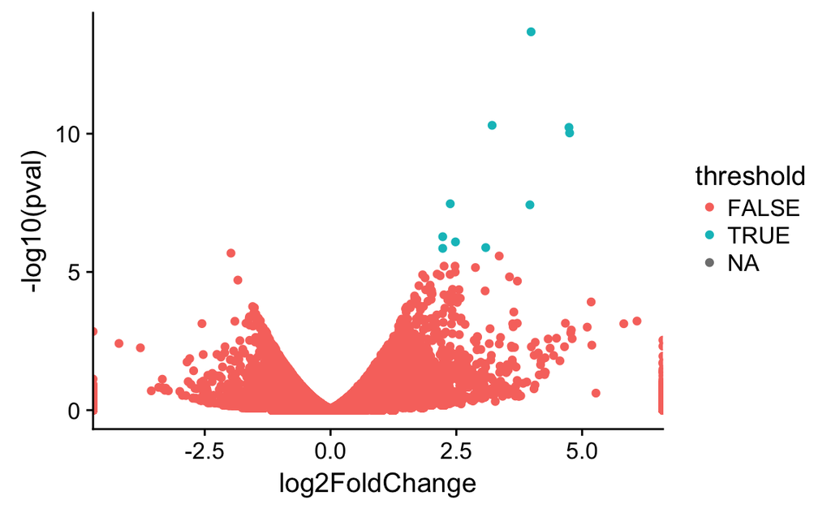

```r
vp <- p + geom_point()
vp
```

Why do we get the warning that almost 4000 rows were removed? A look at my_data reveals that a number of rows have means of 0 and hence missing values for everything that got calculated. Missing values are called NA in R.

```r
missing_data <- my_data %>%
  filter(is.na(threshold))
nrow(missing_data)
```

```
[1] 3696
```

Now that this is clarified, wouldn’t it be nice to have a title and some proper axis labels rather than the column headers?

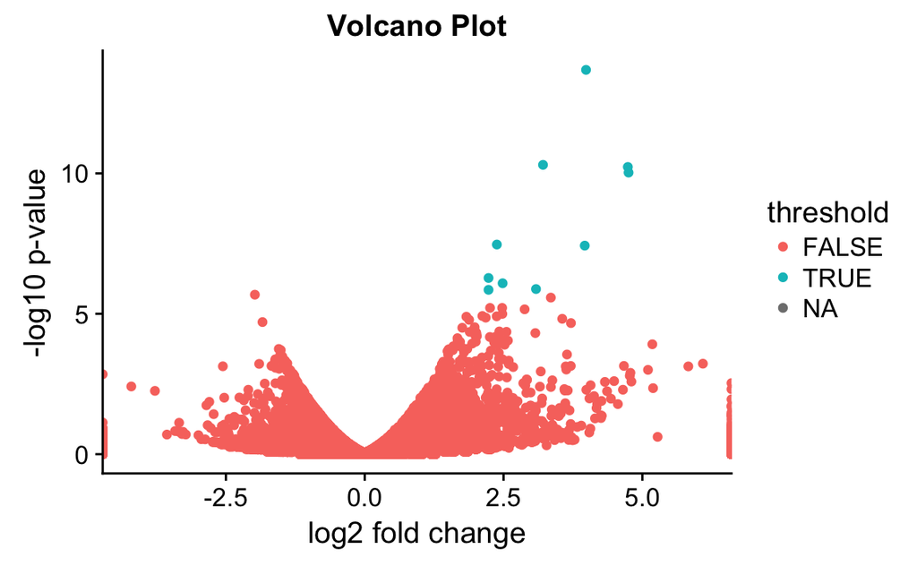

```r
vp <- vp +
  xlab("log2 fold change") +
  ylab("-log10 p-value") +
  ggtitle("Volcano Plot")
vp
```

Let’s add something else:

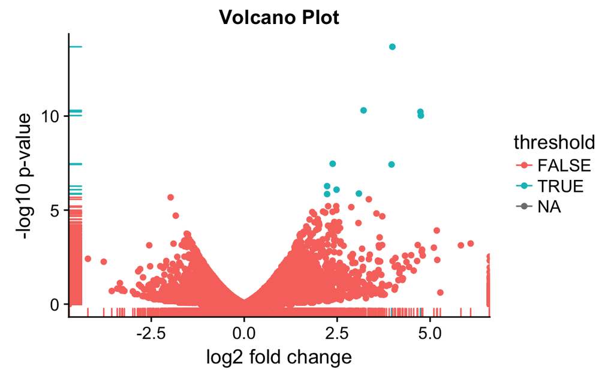

```r
vp <- vp +
  geom_rug()
vp
```

Wouldn’t it be useful to see the gene names next to the dots? Given that we have many thousand dots we don’t expect to be able to read anything but maybe we can add the names to the dots that meet the threshold. for this we use the ifelse function:

```r
?ifelse
```

We run a test (is threshold true) and then we add the label, if it’s False we add nothing (’’)

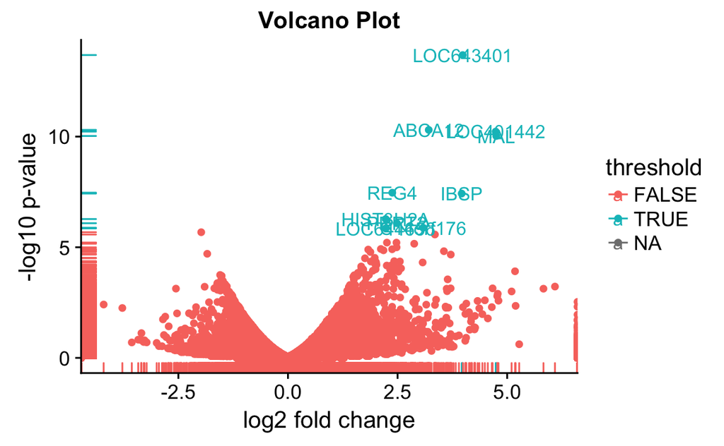

```r
vp_labels <- vp +
  geom_text(aes(label = ifelse(threshold == TRUE, gene, '')))
vp_labels
```

We can improve on this:

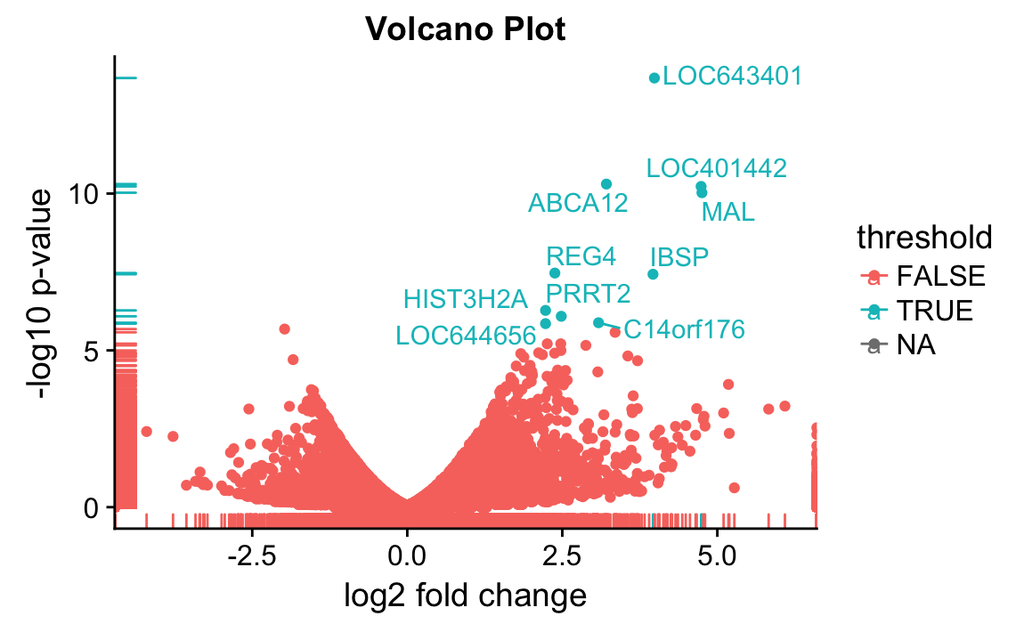

```r
vp_labels <- vp +
    geom_text_repel(aes(label = ifelse(threshold == TRUE, gene, '')))
vp_labels
```

Finally, we may want to remove some clutter, if you haven’t heard of [Edward Tufte](https://en.wikipedia.org/wiki/Edward_Tufte) you might want to check him out.

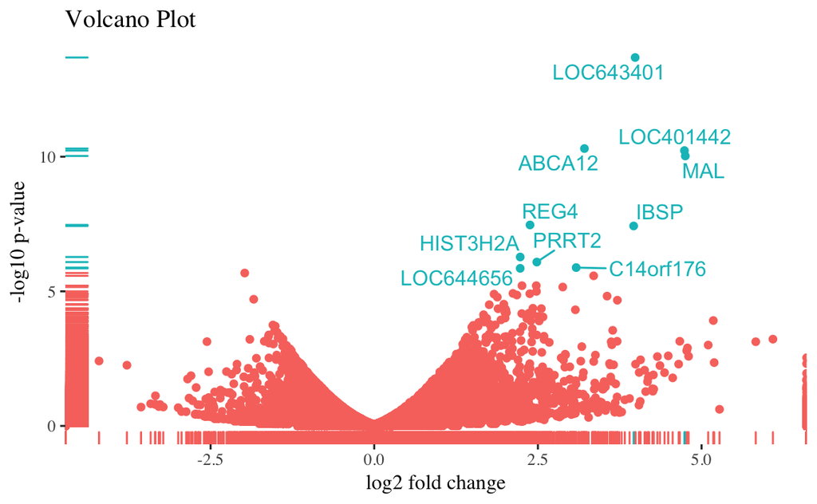

```r
vp_labels <- vp_labels +
  # remove the grid in the background
  theme_tufte() +
  # remove the legend
  theme(legend.position="none")
vp_labels
```

## [GO Terms](http://www.geneontology.org/)

The data shows us which genes are enriched, let’s add some pathway information.

As mentioned in the introduction, there are a lot of packages in R addressed to biologists, the majority of them is found in bioconductor. Some of these packages have complex dependencies and installation can take a few minutes that’s why we don’t use any of these packages in this tutorial. The biomaRt package allows us to get the GO terms for the genes in our dataset. The command looks like this

> library(biomaRt) ensembl<- useMart(“ensembl”,dataset=“hsapiens_gene_ensembl”) gene_goid <- getBM(attributes=c(‘hgnc_symbol’, ‘go_id’, ‘name_1006’), filters = ‘hgnc_symbol’, values = my_data_p05$gene, mart = ensembl)

This query takes a bit of time to run, I saved the results in gene_goid.tsv and we are just going to load them.

This is a good opportunity to check if you remember how to load a csv file. Let’s load the file into a dataframe called “goid”. Use read_tsv this time

```r
goid <- read_tsv("gene_goid.tsv", col_names = TRUE)
goid
```

| gene | go_id | name_1006 |
| --- | --- | --- |
| INPP5D | GO:0004445 | inositol-polyphosphate 5-phosphatase activity |
| INPP5D | GO:0005515 | protein binding |
| INPP5D | GO:0016314 | phosphatidylinositol-3,4,5-trisphosphate 3-phosphatase activity |
| INPP5D | GO:0016787 | hydrolase activity |
| INPP5D | GO:0017124 | SH3 domain binding |
| INPP5D | GO:0034485 | phosphatidylinositol-3,4,5-trisphosphate 5-phosphatase activity |
| INPP5D | GO:0052659 | inositol-1,3,4,5-tetrakisphosphate 5-phosphatase activity |
| INPP5D | GO:0002376 | immune system process |
| INPP5D | GO:0006661 | phosphatidylinositol biosynthetic process |
| INPP5D | GO:0006796 | phosphate-containing compound metabolic process |

[output cut: 990 more lines]

Now we can combine this dataframe with my_data_p05

```r
my_goid_data <- my_data_p05 %>%
  inner_join(goid)
my_goid_data %>% head()
```

| gene | baseMean_all | baseMean_LG3-LG6-LG9 | baseMean_LG2-LG5-LG8 | foldChange | log2FoldChange | pval | padj | go_id | name_1006 |
| --- | --- | --- | --- | --- | --- | --- | --- | --- | --- |
| ABCA12 | 145.1598 | 28.29893 | 262.0206 | 9.259029 | 3.210861 | 4.977065e-11 | 4.311336e-07 | GO:0000166 | nucleotide binding |
| ABCA12 | 145.1598 | 28.29893 | 262.0206 | 9.259029 | 3.210861 | 4.977065e-11 | 4.311336e-07 | GO:0005102 | receptor binding |
| ABCA12 | 145.1598 | 28.29893 | 262.0206 | 9.259029 | 3.210861 | 4.977065e-11 | 4.311336e-07 | GO:0005215 | transporter activity |
| ABCA12 | 145.1598 | 28.29893 | 262.0206 | 9.259029 | 3.210861 | 4.977065e-11 | 4.311336e-07 | GO:0005319 | lipid transporter activity |
| ABCA12 | 145.1598 | 28.29893 | 262.0206 | 9.259029 | 3.210861 | 4.977065e-11 | 4.311336e-07 | GO:0005524 | ATP binding |
| ABCA12 | 145.1598 | 28.29893 | 262.0206 | 9.259029 | 3.210861 | 4.977065e-11 | 4.311336e-07 | GO:0016887 | ATPase activity |

How many individual GO terms do we have here?

```r
nrow(my_goid_data %>% select(go_id) %>% distinct)
```

```
[1] 4586
```

```r
goid_occ <- my_goid_data %>%
  group_by(go_id) %>%
  summarise(occurrences = n()) %>%
  na.omit(go_id)
my_goid_data <- my_goid_data %>%
  inner_join(goid_occ)
my_goid_data
```

| gene | baseMean_all | baseMean_LG3-LG6-LG9 | baseMean_LG2-LG5-LG8 | foldChange | log2FoldChange | pval | padj | go_id | name_1006 | occurrences |
| --- | --- | --- | --- | --- | --- | --- | --- | --- | --- | --- |
| ABCA12 | 145.159768 | 28.298929 | 262.02061 | 9.2590290 | 3.210861 | 4.977065e-11 | 4.311336e-07 | GO:0000166 | nucleotide binding | 102 |
| ABCA12 | 145.159768 | 28.298929 | 262.02061 | 9.2590290 | 3.210861 | 4.977065e-11 | 4.311336e-07 | GO:0005102 | receptor binding | 26 |
| ABCA12 | 145.159768 | 28.298929 | 262.02061 | 9.2590290 | 3.210861 | 4.977065e-11 | 4.311336e-07 | GO:0005215 | transporter activity | 10 |
| ABCA12 | 145.159768 | 28.298929 | 262.02061 | 9.2590290 | 3.210861 | 4.977065e-11 | 4.311336e-07 | GO:0005319 | lipid transporter activity | 3 |
| ABCA12 | 145.159768 | 28.298929 | 262.02061 | 9.2590290 | 3.210861 | 4.977065e-11 | 4.311336e-07 | GO:0005524 | ATP binding | 79 |
| ABCA12 | 145.159768 | 28.298929 | 262.02061 | 9.2590290 | 3.210861 | 4.977065e-11 | 4.311336e-07 | GO:0016887 | ATPase activity | 4 |
| ABCA12 | 145.159768 | 28.298929 | 262.02061 | 9.2590290 | 3.210861 | 4.977065e-11 | 4.311336e-07 | GO:0034040 | lipid-transporting ATPase activity | 1 |
| ABCA12 | 145.159768 | 28.298929 | 262.02061 | 9.2590290 | 3.210861 | 4.977065e-11 | 4.311336e-07 | GO:0034191 | apolipoprotein A-I receptor binding | 1 |
| ABCA12 | 145.159768 | 28.298929 | 262.02061 | 9.2590290 | 3.210861 | 4.977065e-11 | 4.311336e-07 | GO:0042626 | ATPase activity, coupled to transmembrane movement of substances | 2 |
| ABCA12 | 145.159768 | 28.298929 | 262.02061 | 9.2590290 | 3.210861 | 4.977065e-11 | 4.311336e-07 | GO:0006810 | transport | 96 |

[output cut: 990 more lines]

If we had more time we could do an enrichment analysis here. But for now we just have a look at what happens at different locations.

Which proteins undergo more changes, cytosolic or membrane proteins? GO:0005829 indicates cytosol, and GO:0016020 membrane proteins

```r
location_data <- my_goid_data %>%
  filter(go_id == "GO:0005829" | go_id == "GO:0016020")
```

### Violine and Boxplots

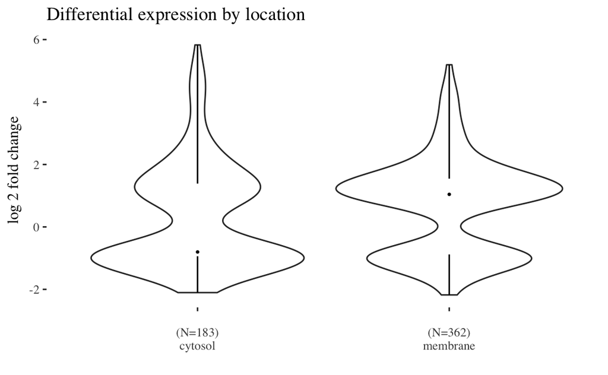

```r
# the next command might appear a bit esoteric, it calculates the number
# of proteins that are cytosolic or membrane proteins
# The paste command prints outputs of various commands together
# see ?paste
xlabs <-
  paste(levels(location_data$name_1006),"\n(N=",table(location_data$name_1006),")",
        "\n", location_data$name_1006, sep="")
p3 <- ggplot(data = location_data, aes(factor(name_1006), log2FoldChange))
violinep <- p3 +
  geom_violin() +
  geom_tufteboxplot() +
  theme_tufte() +
  xlab("") +
  ylab("log 2 fold change") +
  ggtitle("Differential expression by location") +
  scale_x_discrete(labels = xlabs)
violinep
```

### Heatmaps

Bioconductor offers a number of packages that allows you to draw heatmaps including hierarchical clustering. The function heatmap() that is in base R does so too. Since we only have two groups hierarchical clustering doesn’t make a lot of sense. Hence we can just use ggplot2 again. First we look for all results that have a GO term related to “glucose”. For this we use the filter command in combination with grepl. grepl is extremely powerful!

```r
hm_data <- my_goid_data %>%
  filter(grepl("glucose", name_1006)) %>%
  select(gene, `baseMean_LG3-LG6-LG9`, `baseMean_LG2-LG5-LG8`)
# let's rename the columns again
colnames(hm_data) <- c("gene", "LG369","LG258")
```

Before we can use ggplot2 to create a heatmap we have to rearrange our data into a tidy format. Having tidy data has, as the name implies, a number of advantages. I encourage you to follow this link [here](http://vita.had.co.nz/papers/tidy-data.pdf).

```r
hm_long <- hm_data %>%
  gather(key, base_means, -gene)
hm_long %>% head()
```

| gene | key | base_means |
| --- | --- | --- |
| NKX2-2 | LG369 | 1107.64860 |
| PIK3R2 | LG369 | 1317.15892 |
| PIK3R2 | LG369 | 1317.15892 |
| TFF3 | LG369 | 30.88613 |
| OAS1 | LG369 | 116.07490 |
| OAS1 | LG369 | 116.07490 |

This gives us the desired result whith 1 observation per row.

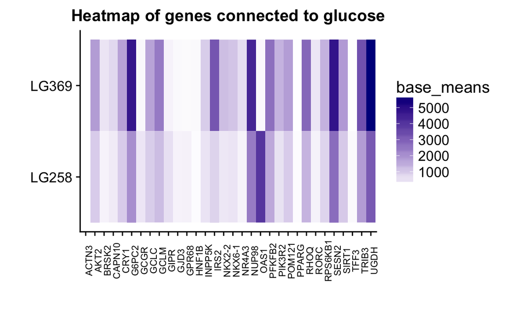

```r
p2 <- ggplot(hm_long, aes(x = gene, y = as.factor(key)))
hm <- p2 +
  geom_tile(aes(fill = base_means)) +
  scale_fill_gradient(low="white", high="darkblue") +
  xlab("") + ylab("") +
  ggtitle("Heatmap of genes connected to glucose") +
  theme(axis.text.x =
          element_text(size = 8,
                       angle = 90,
                       hjust = 0.5))
hm
```

## Putting it all together

We created three plots, the violine plot (violinep), the heatmap (hm), and the volcano plot (vp_label). The package cowplot allows us to combine these figures together with annotation and everything. A lot of people do this in Illustrator or Inkscape. While these vectorgraphics programs yield high quality graphics, working with them can be quite painful. Especially if the figure needs to undergo any sort of modification. cowplot provides a canvas to put on figures and tables and annotations. Its function ggdraw() allows the user to plot things in arbitrary positions. The canvas’s bottom left corner has the x- and y- coordinates of 0, 0 and the top right corner of 1, 1. drow_plot() takes the coordinates plus relative width and height. draw_plot_label adds the labels, it takes the x and y coordinates for each label, and the size as input.

```
Removed 3696 rows containing missing values (geom_point).Removed 3696 rows containing missing values (geom_text_repel).Removed 1 rows containing non-finite values (stat_ydensity).Removed 1 rows containing non-finite values (stat_fivenumber).
```

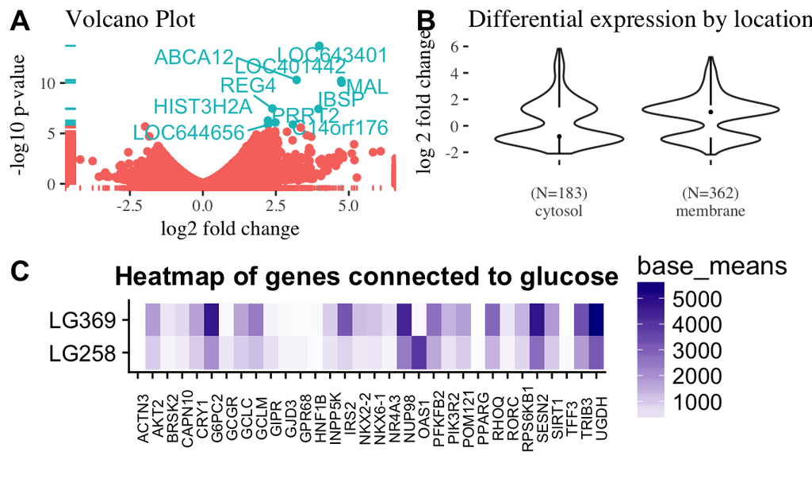

```r
ggdraw() +
  draw_plot(vp_labels, 0, 0.5, 0.5, 0.5) +
  draw_plot(violinep, 0.5, 0.5, 0.5, 0.5) +
  draw_plot(hm, 0, 0, 1, 0.5) +
  draw_plot_label(LETTERS[1:3], c(0, 0.5, 0), c(1, 1, 0.5), size = 15)
```